# Inequalities in PISA scores

D. Moreno and J. Moreno

This document was inspired by [this post](http://freakonometrics.hypotheses.org/16449) by [Arthur Charpentier](https://twitter.com/freakonometrics).

The repository with the code for creating this post is [here](https://github.com/finiterank/pisa). Just some plots so far. We may try something more elaborated or formal (e.g., explicit comparisons of Colombia with other countries) later on.

The data file is available [here](http://beta.icm.edu.pl/PISAcontest/data/student2012.rda).

# Entropy

One possible measure of inequality is entropy, the classical notion developed by Shannon for Information Theory. [This](http://en.wikipedia.org/wiki/Generalized_entropy_index) is a generalized version. I am using here the one with $\alpha=1$.

In the plot country labels are blue for OECD countries and red for non-OECD latin american countries.

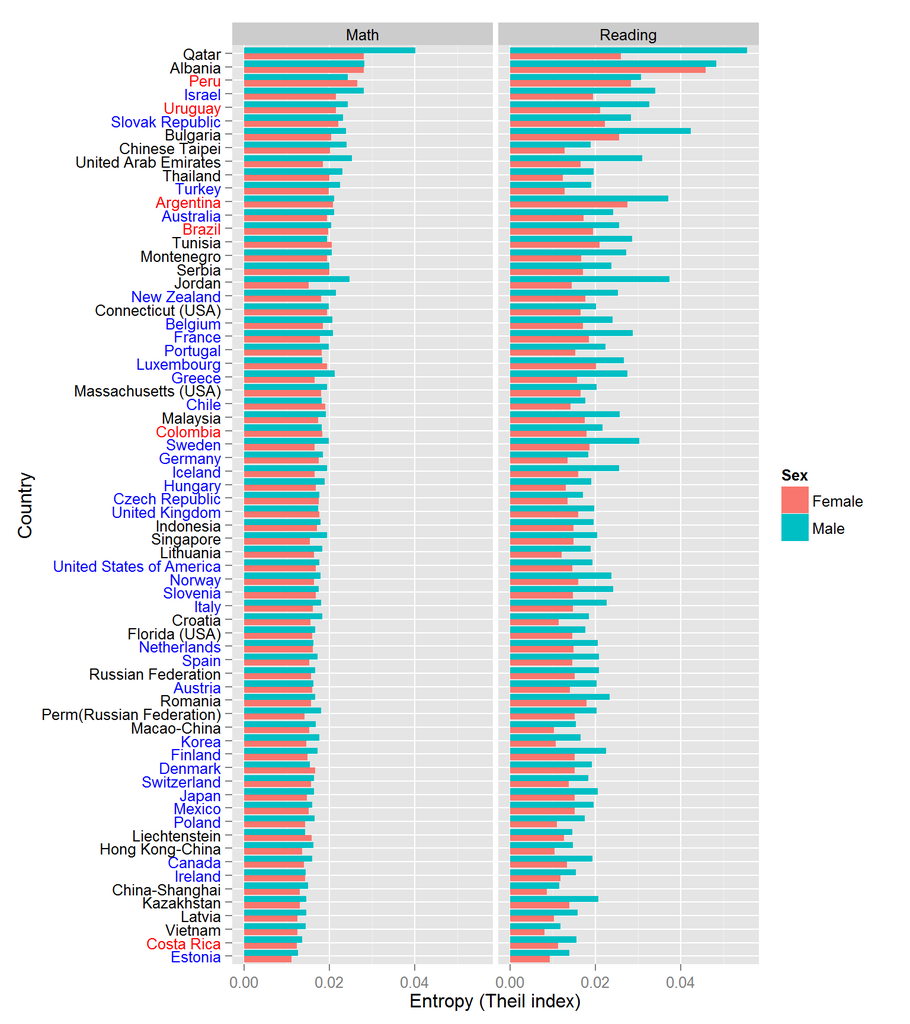

Although entropy is not necessarily a measure of variance, collections of test scores with higher entropy tend to have lower average than those with lower entropy:

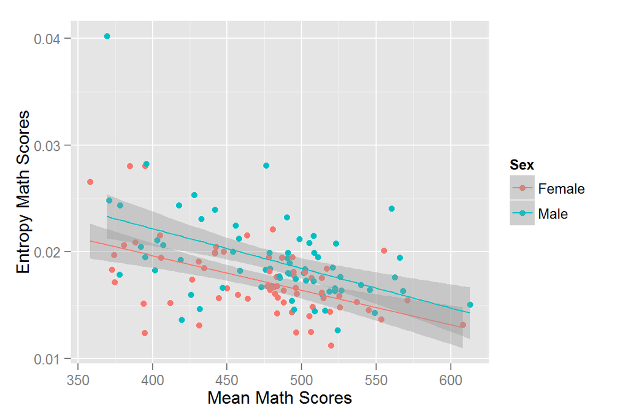

By the way, why is the entropy of female scores (almost) consistently lower than that of males of the same country?

# Standard Deviation

Standard deviation seems to be the most commonly used indicator of performance inequality in standarized test scores. The ranking changes drastically:

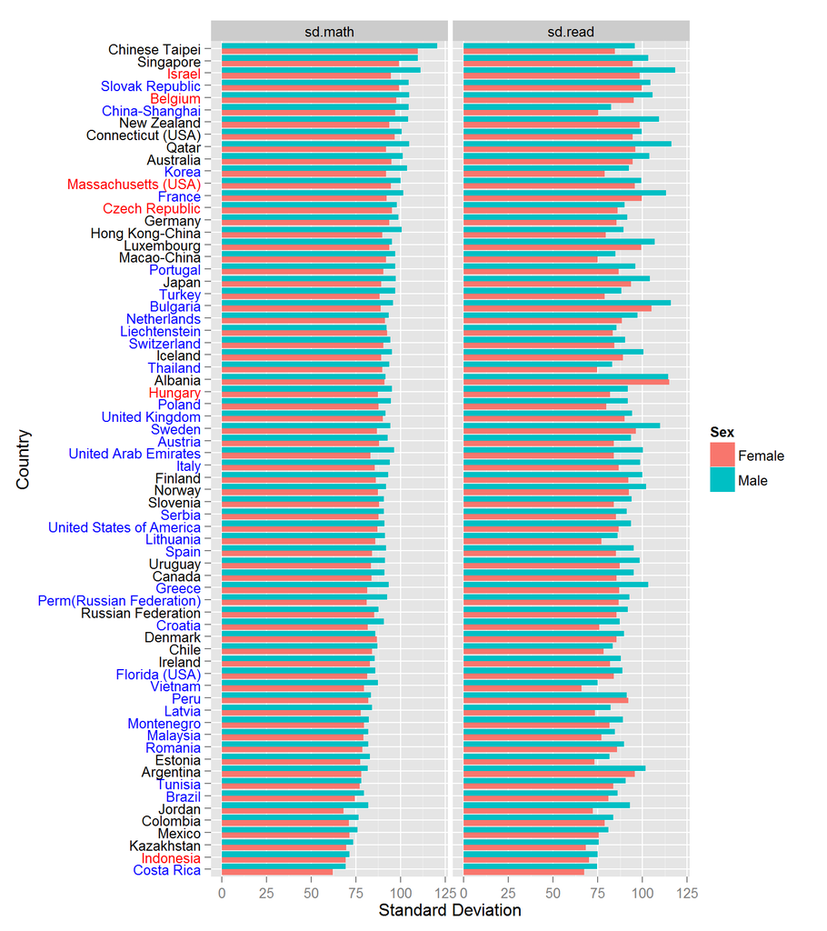

# Distributions of scores (for selected countries)

First, a violin plot of distributions of scores in math (differentiating by sex and ordered by entropy):

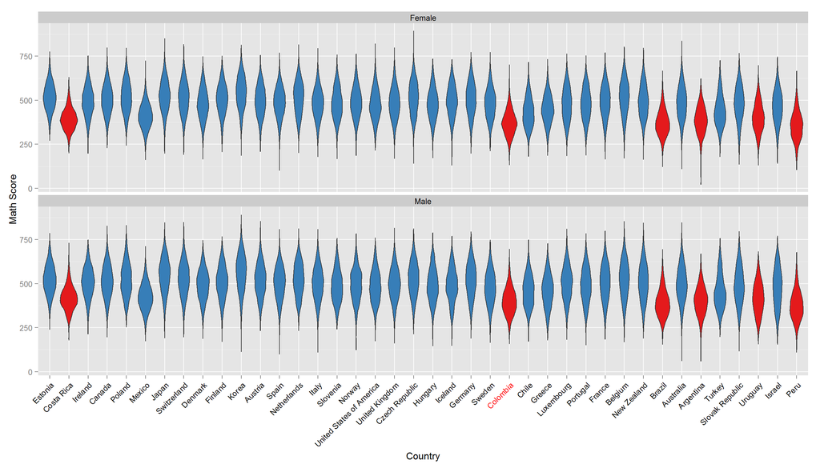

Empirical cummulative density function for each country in math:

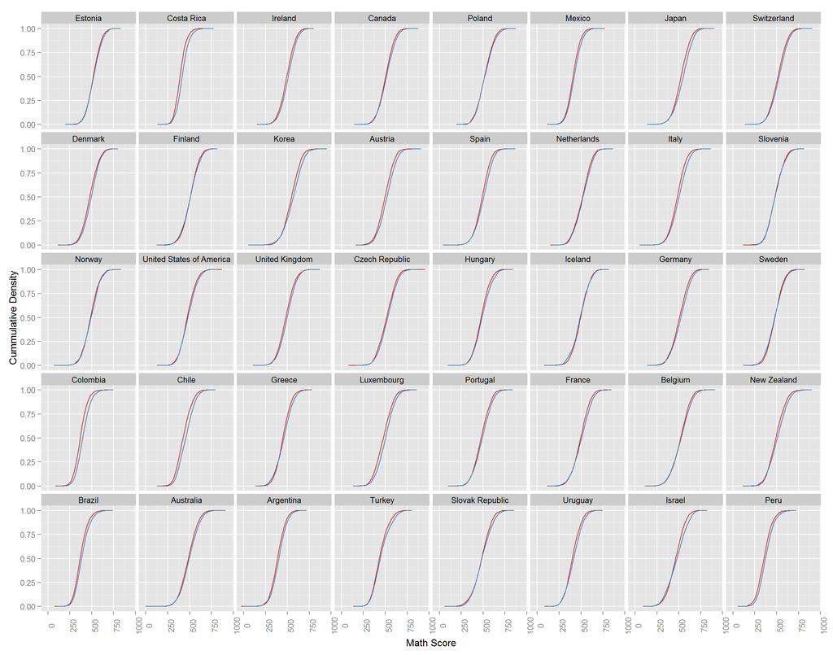

And a kernel density estimate (also for math):

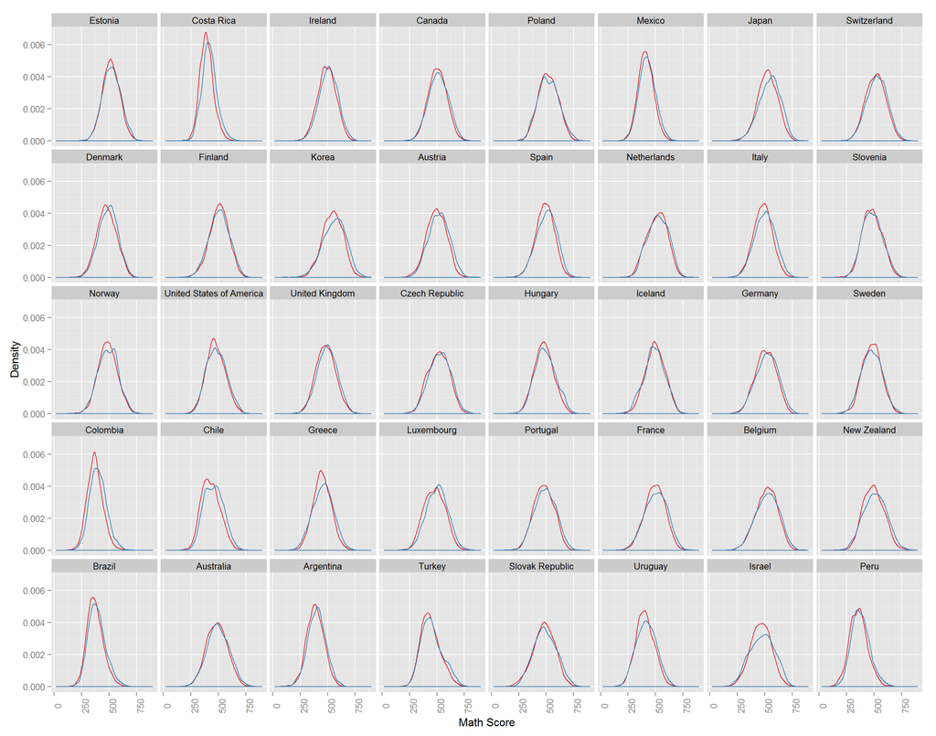

The violin plots show there is a substantial difference between OECD countries and L.A. countries. For instance, note how almost all OECD countries have their median approximately around 500 points while the proportion of Colombian students above that score is just a tail, in fact the median score of OECD countries in math corresponds to the 90.74 quantile of Colombia, that is, 50% of OECD students scored better than *at least* 90.74% of colombian students (!).

# Quantiles

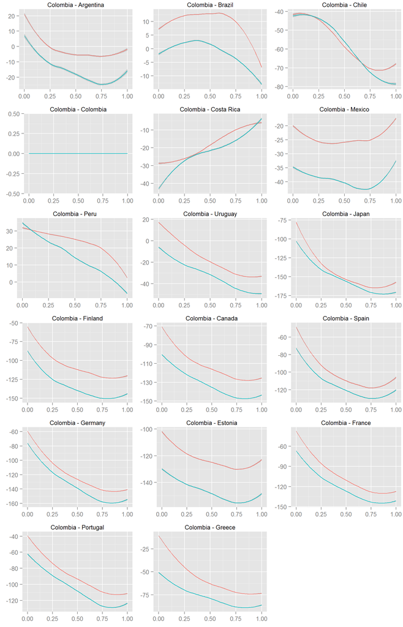

Let’s do the same with Singapore:

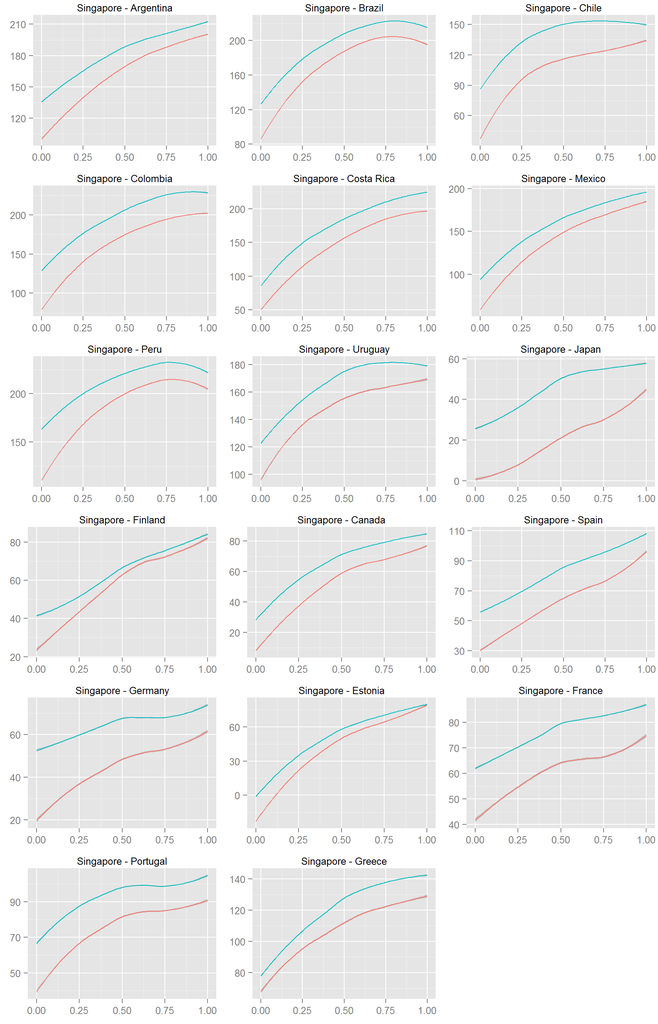

And with the U.S.:

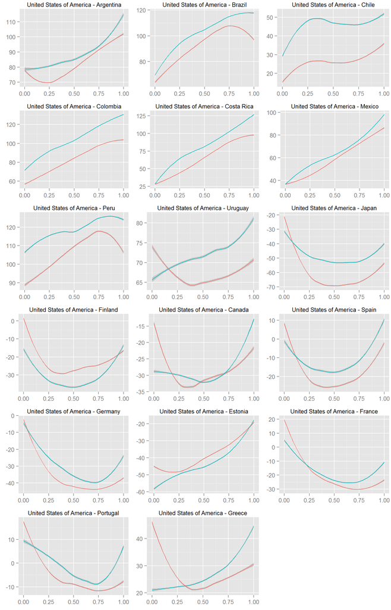

# Quantile averages

Charpentier suggests another way of comparing these distributions: instead of calculating the quantile of the scores for each level, we could calculate the average of the scores above each quantile and, given two countries, take the difference of these values at each level.

Once again, let’s compare Colombia with a bunch of countries:

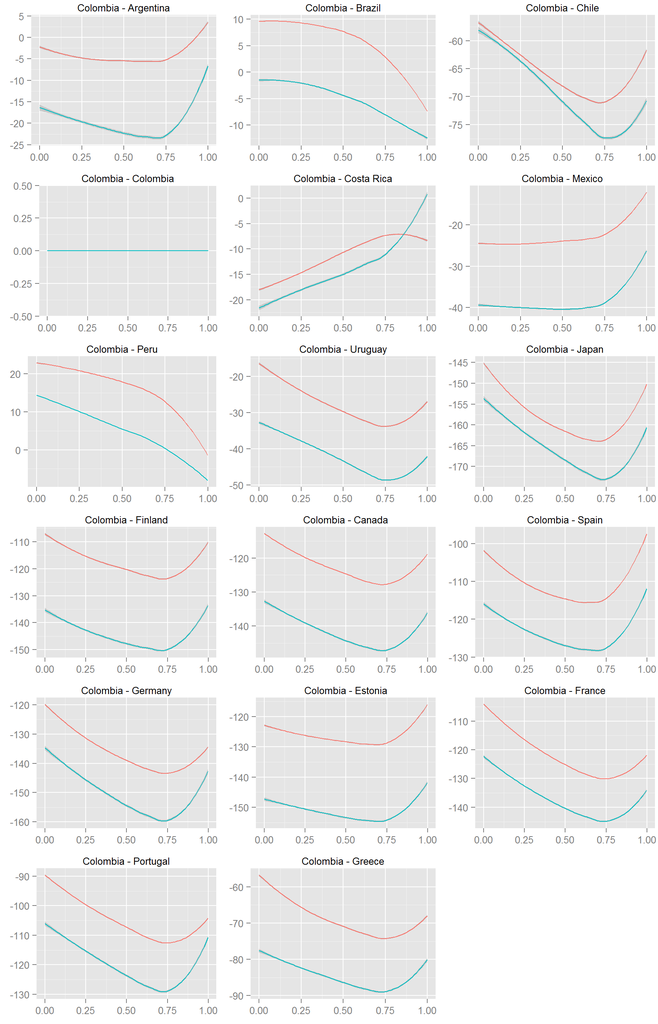

And with the U.S.:

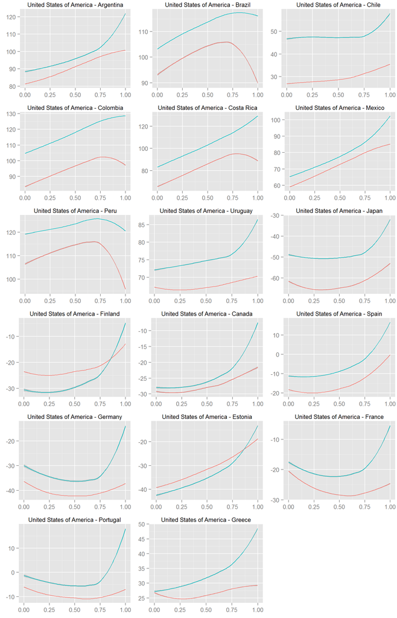

# Further reading

Serious approaches to this problem:

- [The Measurement of Educational Inequaility](http://elibrary.worldbank.org/doi/pdf/10.1596/1813-9450-5873), by Francisco H. G. Ferreira and Jérémie Gignoux
- [Equality of educational opportunity employing PISA data](http://www.urosario.edu.co/urosario_files/f9/f9b47c44-b3d4-49e6-a4c7-cb9b82a2953c.pdf), by Márcia de Carvalho, Luis Fernando Gamboa and Fábio D. Waltenberg